# Understanding mixed effects models through data simulation

Lisa DeBruine and Dale Barr

## Abstract

Experimental designs that sample both subjects and stimuli from a larger population need to account for random effects of both subjects and stimuli using mixed effects models. However, much of this research is analyzed using ANOVA on aggregated responses because researchers are not confident specifying and interpreting mixed effects models. The tutorial will explain how to simulate data with random effects structure and analyse the data using linear mixed effects regression (with the lme4 R package). The focus will be on interpreting the `lmer()` output in light of the simulated parameters. Data simulation can not only enhance understanding of how these models work, but also enables researchers to perform power calculations for complex designs.

## Background

In this article, we walk through the simulation and analysis of multilevel data with crossed random effects of subjects and stimuli. The article’s target audience is researchers who work with experimental designs that sample subjects and stimuli, such as is the case for a large amount of experimental research in face perception, psycholinguistics, or social cognition. The tutorial assumes basic familiarity with R programming.

## Generalizing to a population of encounters

Many research questions in psychology and neuroscience are questions about certain types of *events*: What happens when people encounter particular types of stimuli? For example: Do people recognize abstract words faster than concrete words? What impressions do people form about a target person’s personality based on their vocal qualities? Can people categorize emotional expressions more quickly on the faces of social in-group members than on the faces of out-group members? How do brains respond to threatening versus non-threatening stimuli? In all of these situations, researchers would like to be able to make general statements about phenomena that go beyond the particular participants and particular stimuli that they happen to have chosen for the specific study. Traditionally, people speak of such designs as having crossed random factors of participants and stimuli, and have discussed the problem as one of simultaneous generalization to both populations. However, it may be more intuitive to think of the problem as wanting to generalize to a single population of events: in particular, to a population of *encounters* between the units from the sampled populations (Barr 2018).

Most analyses using conventional statistical techniques, such as analysis of variance and t-test, commit the fallacy of treating stimuli as fixed rather than random. The problem, and the solutions to the problem, have been known in psycholinguistics for over 50 years (Coleman 1964,Clark (1973)), and most psycholinguistic journals require authors to demonstrate generality of findings over stimuli as well as over subjects. Even so, the quasi-$F$ statistics for ANOVA ($F'$ and min-$F'$) that Clark proposed as a solution were widely recognized as unreasonably conservative (Forster and Dickinson 1976), and until fairly recently, most psycholinguists performed separate by-subjects ($F_1$) and by-items analyses ($F_2$), declaring an effect “significant” only if it was significant for both analyses. The $F_1 \times F_2$ approach was widely used, despite the fact that Clark had already shown it to be invalid, since both $F$ statistics have higher than nominal false positives in the presence of a null effect, $F_1$ due to unmodeled stimulus variance, and $F_2$ due to unmodeled subject variance.

Recently, psycholinguists have adopted linear mixed-effects modeling as the standard for the statistical analysis, given numerous advantages over ANOVA, including the ability to simultaneously model subject and stimulus variation, to gracefully deal with missing data or unbalanced designs, and to accommodate arbitrary types of continuous and categorical predictors or response variables (R. H. Baayen, Davidson, and Bates 2008,Locker, Hoffman, and Bovaird (2007)). This development has been facilitated by the `lme4` package for R (D. Bates et al. 2015), which provides powerful functionality for model specification and estimation. With an appropriately specified model, mixed-effects models yield major improvements in power over quasi-$F$ approaches and avoid the increased false positive rate associated with separate $F_1$ and $F_2$ (Barr et al. 2013).

Despite mixed-effects modeling becoming the *de facto* standard for analysis in psycholinguistics, the approach has yet to take hold in other areas where stimuli are routinely sampled, even in spite of repeated calls for improved analyses in social psychology (Judd, Westfall, and Kenny 2012) and neuroimaging (Bedny, Aguirre, and Thompson-Schill 2007,Westfall, Nichols, and Yarkoni (2016)). One of the likely reasons for the limited uptake outside of psycholinguistics is because mixed-effects models expose the analyst to a level of statistical and technical complexity far beyond most researchers’ training. While some of this complexity is specific to mixed-effects modeling, some of it is simply hidden away from users of traditional techniques by GUIs and function defaults. The novice mixed modeler is suddenly confronted with the need to make decisions about how to specify categorical predictors, which random effects to include or exclude, which of the statistics in the voluminous output to attend to, and whether and how to re-configure the optimizer function when a convergence error or singularity warning appears.

We are optimisic that the increasing adoption of the mixed-effects approach will improve the generality and thus reproducibility of studies in psychology and related fields, but empathize with the frustration — and sometimes, exasperation — expressed by many novices when they attempt to grapple with these models in their research. Much of the uncertainty and unease around mixed-effects models comes from using them in situations where the ground truth is unknown. A profitable way to improve understanding and user confidence is through data simulation. Knowing the ground truth allows the user to experiment with various modeling choices and observe their impact on a model’s performance.

## Simulating data with crossed random factors

To give an overview of the simulation task, we will simulate data from a design with crossed random factors of subjects and stimuli, fit a model to the simulated data, and then try to recover the parameter values we put in from the output. In this hypothetical study, subjects classify the emotional expressions of faces as quickly as possible, and we use their response time as the primary dependent variable. Let’s imagine that the faces are of two intrinsic types: either from the subject’s in-group or from an out-group. For simplicity, we further assume that each face appears only once in the stimulus set and expresses only one of two possible emotions (e.g., happiness or anger). The key question is whether there is any difference in classification speed across the type of face.

### Required software

The simulation will be presenting in the R programming language (R Core Team 2018). To run the code, you will need to have some add-on packages available. Any packages you are missing can be installed using R’s `install.packages()` function, except for the development package `faux` (DeBruine 2019) which, at the time of writing, must be installed from the development repository on github.

```r
library("lme4")        # model specification / estimation
library("lmerTest")    # deriving p-values
library("broom.mixed") # extracting data from model fits
library("faux")        # data simulation
# NOTE: to install the 'faux' package, use:
# devtools::install_github("debruine/faux")
library("tidyverse")   # data wrangling and visualisation
```

Because the code uses random number generation, if you want to reproduce the exact results below you will need to set the random number seed at the top of your script and ensure you are using R version 3.6.0 or higher. If you change the seed or are using a lower version of R, your results will differ.

```r
set.seed(8675309)
```

### Establishing the data-generating parameters

The first thing to do is to set up the parameters that govern the process we assume to give rise to the data, the *data-generating process* or DGP. In this hypothetical study, each of 100 subjects will respond to all 50 stimulus items (25 in-group and 25 out-group), for a total of 5000 observations.

```
## # A tibble: 5,000 x 4
##      subj_id item_id condition    RT
##      <chr>   <chr>   <chr>     <dbl>
##    1 S001    I01     ingroup    750.
##    2 S001    I02     ingroup    836.
##    3 S001    I03     ingroup    769.
##      ....    ...     .......    ...
##   25 S001    I25     ingroup    779.
##   26 S001    I26     outgroup   834.
##   27 S001    I27     outgroup   835.
##   28 S001    I28     outgroup   827.
##      ....    ...     .......    ...
##   50 S001    I50     outgroup   802.
##   51 S002    I01     ingroup    807.
##   52 S002    I02     ingroup    806.
##   53 S002    I03     ingroup    759.
##      ....    ...     .......    ...
## 5000 S100    I50     outgroup   860.
```

Note that for independent variables in designs where subjects and stimuli are crossed, you can’t think of factors as being solely “within” or “between” because we have two sampling units; you must ask not only whether independent variables are within- or between- subjects, but also whether they are within- or between- stimulus items. Recall that a within-subjects factor is one where each and every subject receives all of the levels, and a between-subjects factors is one where each subject receives only one of the levels. Likewise, a within-subjects factor is one where each stimulus appears across all of the levels of the independent factors. For our current example, this is clearly not the case, given that each stimulus item is either in-group or out-group.

Let’s first define parameters related to the number of observations.

```r
nsubj  <- 100 # number of subjects
nitem_per_cond  <- 25  # number of items in each condition
```

Getting an appropriately structured dataset is the easy part. The difficult part is randomly generating the RT values. For this, we need to establish an underlying statistical model. Let us start with a basic model and build up from there. We want a model of RT for subject $s$ and item $i$ that looks something like:

$$RT_{si} = \beta_0 + \beta_1 X_{i} + e_{si}$$

In other words, it is the sum of an intercept term $\beta_0$, which we will assume to be the grand mean reaction time for the population of stimuli, plus $\beta_1$, the mean RT difference between in-group and out-group stimuli, plus random noise $e_{si}$. To make $\beta_0$ equal the grand mean and $\beta_1$ the mean out-group minus the mean in-group RT, we will code the `condition` variable as -.5 for the in-group condition and +.5 for the out-group condition.

Although this model is incomplete, we can go ahead and choose parameters for $\beta_0$ and $\beta_1$. For this example, we assume a grand mean of 800 ms and a mean difference of 80 ms.

```r
b0 <- 800 # intercept; i.e., the grand mean
b1 <- 80  # slope; i.e, effect of condition
```

The parameters $\beta_0$ and $\beta_1$ are fixed effects: they are assumed to characterize properties of the population of encounters between subjects and stimuli. Thus, we assume that the mean RT for a “typical” subject encountering a “typical” stimulus is 800 ms, and that responses are typically 80 ms slower for outgroup than ingroup faces.

This model is completely unrealistic, however, because it doesn’t allow for any individual differences among subjects or stimuli. Not all subjects are typical: some will be faster than average, and some slower. We can characterize the difference from the grand mean for each subject $s$ in terms of a *random effect* $S_{0s}$, where the first subscript, 0, indicates that the deflection goes with the intercept term, $\beta_0$. In other words, we assume each subject to have a unique *random intercept*. Likewise, it is unrealistic to assume that it is equally easy to categorize emotional expressions across all faces in the dataset; some will be easier than others. We incorporate this assumption by including by-item random intercepts $I_{0i}$, with the subscript 0 reminding us that it is a deflection from the $\beta_0$ term, and the $i$ indicating a unique deflection for each of the 50 faces. Adding these terms to our model yields:

$$RT_{si} = \beta_0 + S_{0s} + I_{0i} + \beta_1 X_i + e_{si}.$$

Now, the actual values for $S_{0s}$ and $I_{0i}$ in our sampled dataset will depend on the luck of the draw, i.e., on which subject and which stimuli we happened to have sampled from their respective populations. So to capture that these are *random* rather than *fixed* factors, we will set parameters that capture the standard deviation among the random effects and then use these to “sample” from the populations. Below we assume that the by-subject offsets have a standard deviation of 100 ms (`sri_sd`), and the by-item offsets have a standard deviation of 80 ms (`iri_sd`).

```r
sri_sd <- 100 # by-subject random intercept sd
iri_sd <- 80  # by-item random intercept sd
```

There is still a deficiency in our data-generating model related to $\beta_1$, the fixed effect of condition. Currently our model assumes that each and every subject is exactly 80 ms faster to categorize emotions on ingroup faces than on outgroup faces. Clearly, this assumption is totally unrealistic; some participants will be more sensitive to ingroup/outgroup differences than others. We can capture this in an analogous way to which we captured variation in the intercept, namely by including by-subject random slopes $S_{1s}$.

$$RT_{si} = \beta_0 + S_{0s} + I_{0i} + \left(\beta_1 + S_{1s}\right) X_i + e_{si}.$$

A participant who is, on average, 90 ms faster for ingroup faces would have a random slope $S_{1s} = 10$ (90 = 80 + 10); a participant who goes against the grain and is, for whatever reason, 15 ms faster for *outgroup* faces would have a random slope of $S_{1s} = -95$ (-15 = 80 - 95). As we did for the random intercepts, we characterize the random slopes in terms of their standard deviation `srs_sd`, which we assume to be 40 ms.

But note that we are sampling *two* random effects for each subject $s$, a random intercept $S_{0s}$ and a random slope $S_{1s}$. It is possible for these values to be correlated, in which case we should not sample them independently. For instance, perhaps people who are faster than average overall (negative random intercept) also show a smaller then average of the ingroup/outgroup manipulation (negative random slope) due to allocating less attention to the task. We can capture this by allowing for a small correlation between the two factors, `rcor`, which we assume to be .2.

Finally, we need to characterize the trial-level noise in the study (the $e_{si}$s) in terms of their standard deviations. Here we simply assume this parameter value `err_sd` to be twice the size of the by-subject random intercept SD.

```r
srs_sd <- 40  # by-subject random slope sd
rcor <- .2    # correlation between intercept and slope

# random noise (error)
err_sd <- 200 # residual sd
```

To summarize, we established a reasonable statistical model underlying the data having the form:

$$RT_{si} = \beta_0 + S_{0s} + I_{0i} + \left(\beta_1 + S_{1s}\right) X_i + e_{si}$$

where the response time for subject $s$ on item $i$, $RT_{si}$, is decomposed into a population grand mean $\beta_0$, a by-subject random intercept $S_{0s}$, a by-item random intercept $I_{0i}$, a fixed slope $\beta_1$, by-subject random slopes $S_{1s}$, and a trial-level residual $e_{si}$. Our data-generating process is fully determined by seven parameters: two fixed effects (intercept and slope), four variance parameters governing the random effects (defined in the code as `sri_sd`, `srs_sd`, `rcor`, and `iri_sd`), and one parameter governing the trial level variance (`err_sd`).

In the next section we will apply this data-generating process to simulate the sampling of subjects, items, and trials (encounters).

### Simulating the sampling process

#### Simulate the sampling of stimulus items

We need to create a table listing each item, which condition it is in, and simulated values for its random effects.

We will simulate items using the function `sim_design()` from faux. This function will create a dataset with `n` items per between-cell with the specified means (`mu`), standard deviations (`sd`) and correlations (`r`). See the [vignette](https://debruine.github.io/faux/articles/sim_design.html) for more details.

Condition is a between-items factor, so we need to include it in the `between` argument. Set `n = nitem_per_cond` to specify 25 items per condition. Set `sd = iri_sd` to set the standard deviation for the by-item random effects. Set `dv = "I0i"` to give the random effect column that name. Set `id = "item_id"`; we’ll use this later to join this information to the table of trials.

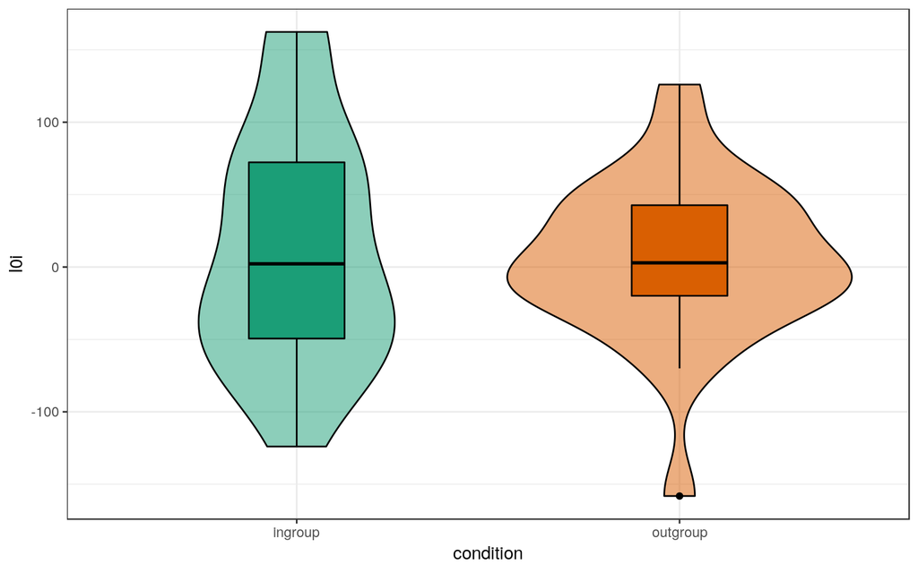

The distribution of random effects for ingroup and outgroup faces.

```r
items <- faux::sim_design(
  between = list(condition = c("ingroup", "outgroup")),
  n = nitem_per_cond,
  sd = iri_sd,
  dv = "I0i",
  id = "item_id",
  plot = FALSE
)

plot_design(items)
```

We will also introduce a numerical predictor to represent what condition each stimulus item $i$ appears in (i.e., for the $X_i$ in our model). Since we predict that responses to ingroup faces will be faster than outgroup faces, we set ingroup to -0.5 and outgroup to +0.5.

```r
# effect code condition
items$cond <- recode(items$condition, "ingroup" = -0.5, "outgroup" = +0.5)
```

Let’s have a look at the resulting table.

```r
head(items)
```

```
##   item_id condition       I0i cond
## 1     S01   ingroup -79.72659 -0.5
## 2     S02   ingroup  57.74593 -0.5
## 3     S03   ingroup -49.37671 -0.5
## 4     S04   ingroup 162.35133 -0.5
## 5     S05   ingroup  85.23328 -0.5
## 6     S06   ingroup  78.97758 -0.5
```

#### Simulate the sampling of subjects

Now we will simulate the sampling of individual subjects, resulting in a table listing each subject and their two random effects. We will again use `faux::sim_design()` for this task.

Set the `within` argument in `sim_design()` to a list with one factor (`effect`) that has two levels: `S0s` and `S1s`. If you set a factor’s levels as a named vector, the names (`S0s` and `S1s`) become the column names in the data table and the values are used in plots created by faux.

Set `n = nsubj` to specify the number of subjects. There are two random effects to specify standard deviation for, so set `sd` using a named vector and set their correlation with `r = rcor`. Set `dv = "value"`; this will only be used in faux plots. Set `id = "subj_id"`; we’ll use this later to join this information to the table of trials.

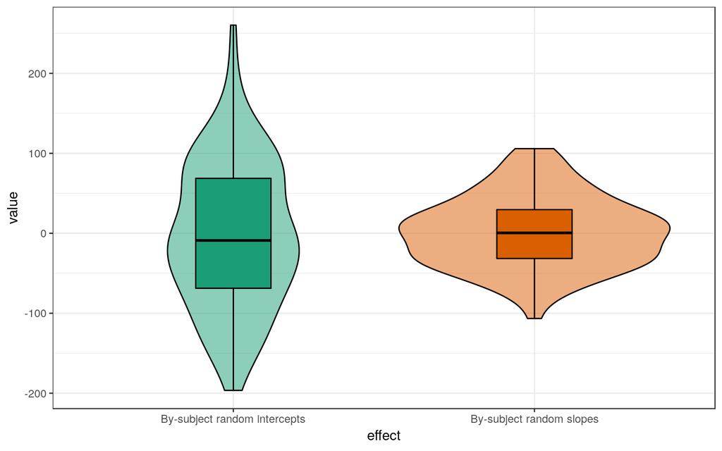

The distribution of random effects for subjects

```r
subjects <- faux::sim_design(
  within = list(effect = c(S0s = "By-subject random intercepts",
                           S1s = "By-subject random slopes")),
  n = nsubj,
  sd = c(sri_sd = sri_sd, srs_sd = srs_sd),
  r = rcor,
  dv = "value",
  id = "subj_id",
  plot = FALSE
)

plot_design(subjects)
```

Let’s have a look at the resulting table.

```r
head(subjects)
```

```
##   subj_id        S0s       S1s
## 1    S001 -14.651591  11.13222
## 2    S002  -8.394393 -36.66282
## 3    S003  87.723506 -47.51720
## 4    S004 209.347135  62.86501
## 5    S005 -23.625182  21.48579
## 6    S006  90.138972  56.65113
```

#### Simulate trials (encounters)

Since all subjects respond to all items, we can set up a table of trials by crossing the subject IDs with the item IDs. Each trial has random error associated; we simulate this from a normal distribution with a mean of 0 and SD of `err_sd`.

```r
# crossing() is from the tidyr package;
# see ?tidyr::crossing for details
trials <- crossing(subj_id = subjects$subj_id,
                   item_id = items$item_id) %>%
  mutate(err = rnorm(nrow(.), mean = 0, sd = err_sd))
```

Have a look:

```r
head(trials)
```

```
## # A tibble: 6 x 3
##   subj_id item_id    err
##   <chr>   <chr>    <dbl>
## 1 S001    S01      -66.5
## 2 S001    S02      -34.7
## 3 S001    S03      -37.5
## 4 S001    S04      231.
## 5 S001    S05     -188.
## 6 S001    S06      105.
```

### Calculate the response values

Now that we have a table of all trials, we can join the information in this table to the information in our `subjects` and `items` tables. We join them together using `dplyr::inner_join()`.

```r
joined <- trials %>%
  inner_join(subjects, "subj_id") %>%
  inner_join(items, "item_id")

joined
```

```
## # A tibble: 5,000 x 8
##    subj_id item_id     err   S0s   S1s condition     I0i  cond
##    <chr>   <chr>     <dbl> <dbl> <dbl> <fct>       <dbl> <dbl>
##  1 S001    S01      -66.5  -14.7  11.1 ingroup    -79.7   -0.5
##  2 S001    S02      -34.7  -14.7  11.1 ingroup     57.7   -0.5
##  3 S001    S03      -37.5  -14.7  11.1 ingroup    -49.4   -0.5
##  4 S001    S04      231.   -14.7  11.1 ingroup    162.    -0.5
##  5 S001    S05     -188.   -14.7  11.1 ingroup     85.2   -0.5
##  6 S001    S06      105.   -14.7  11.1 ingroup     79.0   -0.5
##  7 S001    S07      -25.6  -14.7  11.1 ingroup      2.20  -0.5
##  8 S001    S08     -365.   -14.7  11.1 ingroup     53.8   -0.5
##  9 S001    S09      107.   -14.7  11.1 ingroup     45.8   -0.5
## 10 S001    S10        8.09 -14.7  11.1 ingroup     72.3   -0.5
## # … with 4,990 more rows
```

Note how this resulting table contains the full decomposition of effects that we need to compute the response according to the linear model we defined above:

$$RT_{si} = \beta_0 + S_{0s} + I_{0i} + \left(\beta_1 + S_{1s}\right) X_i + e_{si}.$$

Thus, we will calculate the response variable `RT` by adding together:

- the grand intercept (`b0`),
- each subject-specific random intercept (`S0s`),
- each item-specific random intercept (`I0i`),
- each sum of the condition effect (`b1`) and the random slope (`S1s`), multiplied by the numerical predictor (`cond`), and
- each residual error (`err`).

After this we will use `dplyr::select()` to keep the columns we need for the analysis process. Note that the resulting table has the structure that we set as our goal at the start of this exercise, with the addition of the numerical predictor variable `cond`.

```r
dat_sim <- joined %>%
  mutate(RT = b0 + S0s + I0i + (b1 + S1s) * cond + err) %>%
  select(subj_id, item_id, condition, cond, RT)

dat_sim
```

```
## # A tibble: 5,000 x 5
##    subj_id item_id condition  cond    RT
##    <chr>   <chr>   <fct>     <dbl> <dbl>
##  1 S001    S01     ingroup    -0.5  594.
##  2 S001    S02     ingroup    -0.5  763.
##  3 S001    S03     ingroup    -0.5  653.
##  4 S001    S04     ingroup    -0.5 1133.
##  5 S001    S05     ingroup    -0.5  637.
##  6 S001    S06     ingroup    -0.5  924.
##  7 S001    S07     ingroup    -0.5  716.
##  8 S001    S08     ingroup    -0.5  428.
##  9 S001    S09     ingroup    -0.5  892.
## 10 S001    S10     ingroup    -0.5  820.
## # … with 4,990 more rows
```

### Analyze Data

Now we’re ready to analyse our simulated data with the `lmer()` function from the `lme4` package. The first argument to `lmer()` is a model formula that defines the structure of the linear model. For our design, we will use:

`RT ~ cond + (cond | subj_id) + (1 | item_id)`

The ‘fixed’ part of the formula, `RT ~ cond`, is a shorthand way of establishing the $RT_{si} + \beta_0 + \beta_1 X_i + e_{si}$ part of our linear model, with the role of $X_i$ being played by `cond`. Because every model has an intercept ($\beta_0$) terms and residual term ($\e_{si}$) by default, these are left implicit. To make the intercept explicit, we could have written `RT ~ 1 + cond` instead.

The terms in parentheses with the `|` separator define the random effects structure. For each of these bracketed terms, the left-hand side of the `|` names the effects you wish to allow to vary, the right hand side names the variable identifying the levels of the random factor over which the terms vary (e.g., subjects or items). The first term, `(cond | subj_id)`, is an instruction to allow the effect of condition (`cond`) to vary over the random factor of subjects (`subj_id`). As for the fixed part, this syntax also calls for a by-subject random intercept, although it is left implicit; if we wanted to make it explicit, we would write `(1 + cond | subj_id)` instead, which accomplishes the same thing. You could think of this first term as establishing `S0s` and `S1s` in our model, but it is more accurate to think of it as an instruction to estimate the three parameters that underlie the `S0s` and `S1s` values, namely `sri_sd`, `srs_sd`, and `rcor`. The second term, `(1 | item_id)`, calls for a by-item random intercept, and will call for estimation of the parameter generating the `I0i` values, namely `iri_sd`

```r
mod_sim <- lmer(RT ~ cond + (cond | subj_id) + (1 | item_id),
                data = dat_sim, REML = TRUE)
```

Use the `summary()` function to view the results. Let’s break down the output step-by-step and try to find estimates of the seven parameters we used to generate the data: `b0`, `b1`, `sri_sd`, `srs_sd`, `rcor`, `iri_sd` and `err`.

```r
summary(mod_sim)
```

After providing general information about the model fit, the output is divided into a `Random effects` and a `Fixed effects` section. Let us start with the fixed effects section, as this should be familiar from other types of linear models.

```
##             Estimate Std. Error     df t value Pr(>|t|)
## (Intercept)   807.72      13.19 119.05   61.26  < 2e-16 ***
## cond           69.47      19.79  56.30    3.51  0.00089 ***
```

The `Estimate` column gives us parameter estimates for the fixed effects in the model, i.e., $\hat{\beta_0}$ and $\hat{\beta_1}$, which are estimated at about 808 and 69. The next columns give us the standard errors, estimated degrees of freedom (using the Satterthwaite approach), $t$ value, and finally, $p$ value.

The `Random effects` section is specific to mixed-effects models, and will be less familiar to the reader.

```
##  Groups   Name        Variance Std.Dev. Corr
##  subj_id  (Intercept)  8416     91.74
##           cond         3298     57.43   0.12
##  item_id  (Intercept)  4072     63.81
##  Residual             41283    203.18
```

These are the estimates for the *variance components* in the model. To avoid confusion, it is best to think of the information in this table as coming from three separate tables divided up by the values in the `Groups` column.

The first subtable, where the value of `Groups` is `subj_id`, gives the estimates for the variance parameters defining the by-subject random effects.

```
##  Groups   Name        Variance Std.Dev. Corr
##  subj_id  (Intercept)  8416     91.74
##           cond         3298     57.43   0.12
```

We have estimates for the variance of the intercept and slope (`cond`) in the `Variance` column, which is just the square of the standard deviation in the `Std.Dev.` column. We obtain estimates for `sri_sd` and `srs_sd` of 91.74 and 57.43 respectively. The `Corr.` column gives us the estimated correlation between the by-subject random intercepts and slopes, estimated here as 0.12.

The second subtable gives us the by-item random effect parameter estimates of which there is only one, 63.81, corresponding to `iri_sd`. Again, the `Variance` column is just this value squared.

```
##  Groups   Name        Variance Std.Dev. Corr
##  item_id  (Intercept)  4072     63.81
```

The last subtable is gives us the estimate of the residual term, 203.18.

```
##  Groups   Name        Variance Std.Dev. Corr
##  Residual             41283    203.18
```

We have found all seven parameters in the output. Let’s compare them to the values that we put in.

| variable | explanation | simulated value | estimate |
| --- | --- | --- | --- |
| `b0` | grand mean (intercept) | 800 | 807.72 |
| `b1` | effect of condition | 80 | 69.47 |
| `iri_sd` | by-item random intercept SD | 80 | 63.81 |
| `sri_sd` | by-subject random intercept SD | 100 | 91.74 |
| `srs_sd` | by-subject random slope SD | 40 | 57.43 |
| `rcor` | cor between intercept and slope | 0.2 | 0.12 |
| `err_sd` | residual SD | 200 | 203.18 |

You can also use `broom.mixed::tidy()` to output fixed and/or random effects in a tidy table. This is especially useful when you need to combine the output from hundreds of simulations to calculate power.

```r
broom.mixed::tidy(mod_sim)
```

```
## # A tibble: 7 x 8
##   effect  group   term         estimate std.error statistic    df   p.value
##   <chr>   <chr>   <chr>           <dbl>     <dbl>     <dbl> <dbl>     <dbl>
## 1 fixed   <NA>    (Intercept)   808.         13.2     61.3  119.   7.22e-92
## 2 fixed   <NA>    cond           69.5        19.8      3.51  56.3  8.90e- 4
## 3 ran_pa… subj_id sd__(Interc…   91.7        NA       NA     NA   NA
## 4 ran_pa… subj_id sd__cond       57.4        NA       NA     NA   NA
## 5 ran_pa… subj_id cor__(Inter…    0.121      NA       NA     NA   NA
## 6 ran_pa… item_id sd__(Interc…   63.8        NA       NA     NA   NA
## 7 ran_pa… Residu… sd__Observa…  203.         NA       NA     NA   NA
```

### Calculate Power

Data simulation is useful not only for illuminating modeling approaches, but also for calculating power when planning a study. The basic idea of a power simulation is to generate a large number of datasets encoding your assumptions about likely parameter values, fit models to each dataset, and then calculate the proportion of models that reject the null hypothesis as a measure of power.

To do this, you’ll need to set up a function that takes all of the parameters we set above as arguments. We’ll set the to default to the values we used, but you can choose your own defaults. The code below is just all of the code above, condensed a bit.

```r
my_sim_func <- function(nsubj  = 100, # number of subjects pre between-subject cell
                        nitem  = 25,  # number of items per between-item cell
                        b0     = 800, # grand mean
                        b1     = 80,  # effect of condition
                        iri_sd = 80,  # by-item random intercept sd (omega_00)
                        sri_sd = 100, # by-subject random intercept sd
                        srs_sd = 40,  # by-subject random slope sd
                        rcor   = .2,  # correlation between intercept and slope
                        err_sd = 200  # residual (standard deviation)
                        ) {
  # simulate items
  items <- faux::sim_design(
    between = list(condition = c("ingroup", "outgroup")),
    n = nitem,
    sd = iri_sd,
    dv = "I0i",
    id = "item_id",
    plot = FALSE
  )

  # effect code condition
  items$cond <- recode(items$condition, "ingroup" = -0.5, "outgroup" = 0.5)

  # simulate subjects
  subjects <- faux::sim_design(
    within = list(effect = c(S0s = "By-subject random intercepts",
                             S1s = "By-subject random slopes")),
    n = nsubj,
    sd = c(sri = sri_sd, srs = srs_sd),
    r = rcor,
    dv = "value",
    id = "subj_id",
    plot = FALSE
  )

  # simulate trials
  dat_sim <- crossing(subj_id = subjects$subj_id,
                     item_id = items$item_id) %>%
    mutate(err = rnorm(nrow(.), mean = 0, sd = err_sd)) %>%
    inner_join(subjects, "subj_id") %>%
    inner_join(items, "item_id") %>%
    mutate(RT = b0 + S0s + I0i + (b1 + S1s) * cond + err)

  mod_sim <- lmer(RT ~ cond + (1 | item_id) + (1 + cond | subj_id),
                dat_sim, REML = FALSE)

  broom.mixed::tidy(mod_sim)
}
```

Let’s test the function out by running it once with default parameters.

```r
my_sim_func()
```

```
## # A tibble: 7 x 8
##   effect  group   term         estimate std.error statistic    df   p.value
##   <chr>   <chr>   <chr>           <dbl>     <dbl>     <dbl> <dbl>     <dbl>
## 1 fixed   <NA>    (Intercept)   813.         14.3     56.9  115.   2.93e-86
## 2 fixed   <NA>    cond          113.         21.8      5.19  53.3  3.34e- 6
## 3 ran_pa… subj_id sd__(Interc…   94.5        NA       NA     NA   NA
## 4 ran_pa… subj_id sd__cond       41.4        NA       NA     NA   NA
## 5 ran_pa… subj_id cor__(Inter…    0.188      NA       NA     NA   NA
## 6 ran_pa… item_id sd__(Interc…   73.2        NA       NA     NA   NA
## 7 ran_pa… Residu… sd__Observa…  199.         NA       NA     NA   NA
```

You can use the `purrr::map_df` function to run the simulation repeatedly and save the results to a data table. This will take a while, so test using just a few reps first, then make sure you save the full results to a CSV file so you can set this code chunk to not run (`eval = FALSE` in the chunk header) and load from the saved data for the rest of your script in the future.

```r
reps <- 1000
sims <- purrr::map_df(1:reps, ~my_sim_func())
write_csv(sims, "sims.csv")
```

```r
sims <- read_csv("sims.csv")
```

You can use these data to calculate power for each fixed effect or plot the distribution of your fixed or random effects. The code for doing this is given in the online appendix to this article.

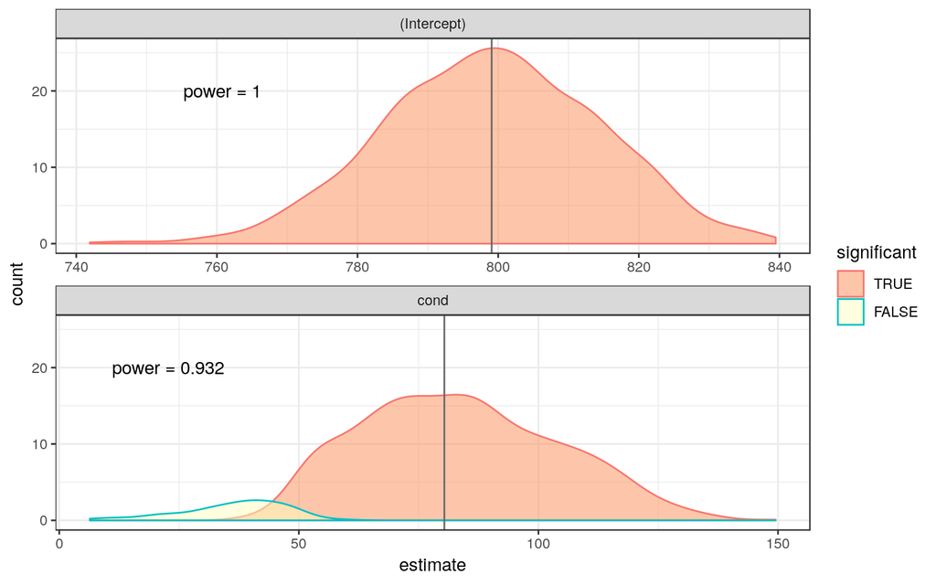

Distribution of fixed effects across 1000 simulations

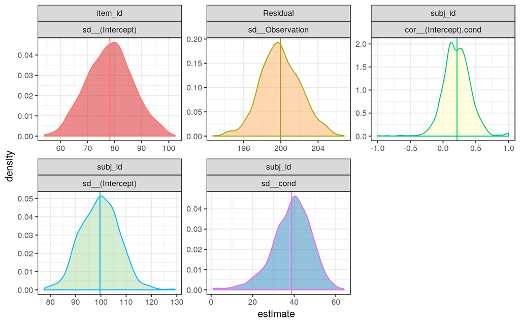

Distribution of random effects across 1000 simulations

## Conclusion

Mixed-effects modeling is a powerful technique for analyzing data from complex designs. The technique is close to ideal for analyzing data with crossed random factors of subjects and stimuli: it gracefully and simultaneously accounts for subject and item variance within a single analysis, and outperforms traditional techniques in terms of type I error and power. However, this additional power comes at the price of technical complexity. Through this article, we have attempted to make mixed-effects models more approachable using data simulation.

We also have not said much in this tutorial about estimation issues, such as what to do when the fitting procedure fails to converge. Further guidance on this point can be found in (Barr et al. 2013), and by consulting the help materials in the `lme4` package (`?lme4::convergence`). We have also assumed that the random effects specification for the `lmer()` function should be based on the study design. However, we note that others have argued in favor of data-driven approaches for random effects specification (Matuschek et al. 2017).

## References

Baayen, R. H., D. J. Davidson, and D. M. Bates. 2008. “Mixed-Effects Modeling with Crossed Random Effects for Subjects and Items.” *Journal of Memory and Language* 59: 390–412.

Barr, Dale J. 2013. “Random Effects Structure for Testing Interactions in Linear Mixed-Effects Models.” *Frontiers in Psychology* 4: 328.

———. 2018. “Generalizing over encounters: Statistical and theoretical considerations.” In *Oxford Handbook of Psycholinguistics*, edited by S.-A. Rueschemeyer and M. G. Gaskell. Oxford University Press.

Barr, Dale J, Roger Levy, Christoph Scheepers, and Harry J Tily. 2013. “Random effects structure for confirmatory hypothesis testing: Keep it maximal.” *Journal of Memory and Language* 68 (3): 255–78.

Bates, Douglas, Martin Mächler, Ben Bolker, and Steve Walker. 2015. “Fitting Linear Mixed-Effects Models Using lme4.” *Journal of Statistical Software* 67 (1): 1–48. doi:10.18637/jss.v067.i01.

Bedny, Marina, Geoffrey K Aguirre, and Sharon L Thompson-Schill. 2007. “Item Analysis in Functional Magnetic Resonance Imaging.” *Neuroimage* 35 (3). Elsevier: 1093–1102.

Clark, Herbert H. 1973. “The language-as-fixed-effect fallacy: A critique of language statistics in psychological research.” *Journal of Verbal Learning and Verbal Behavior* 12. Elsevier: 335–59.

Coleman, Edmund B. 1964. “Generalizing to a Language Population.” *Psychological Reports* 14: 219–26.

DeBruine, Lisa. 2019. *Faux (Beta) (Version V0.0.0.9013-Beta)*. Zenodo. doi:10.5281/zenodo.2669587.

Forster, K., and R. Dickinson. 1976. “More on the Language-as-Fixed-Effect Fallacy: Monte Carlo Estimates of Error Rates for $F_1$,$F_2$,$F'$, and Min $F'$.” *Journal of Verbal Learning and Verbal Behavior* 15: 135–42.

Judd, Charles M, Jacob Westfall, and David A Kenny. 2012. “Treating stimuli as a random factor in social psychology: A new and comprehensive solution to a pervasive but largely ignored problem.” *Journal of Personality and Social Psychology* 103: 54.

Locker, Lawrence, Lesa Hoffman, and James Bovaird. 2007. “On the Use of Multilevel Modeling as an Alternative to Items Analysis in Psycholinguistic Research.” *Behavior Research Methods* 39: 723–30.

Matuschek, Hannes, Reinhold Kliegl, Shravan Vasishth, Harald Baayen, and Douglas Bates. 2017. “Balancing Type I Error and Power in Linear Mixed Models.” *Journal of Memory and Language* 94. Elsevier: 305–15.

R Core Team. 2018. *R: A Language and Environment for Statistical Computing*. Vienna, Austria: R Foundation for Statistical Computing. https://www.R-project.org/.

Westfall, Jacob, Thomas E Nichols, and Tal Yarkoni. 2016. “Fixing the stimulus-as-fixed-effect fallacy in task fMRI.” *Wellcome Open Research* 1. The Wellcome Trust.